# Tubakareklaamid Eesti ajalehtedes 1920-1940

### Vaatame, kuidas näeb välja sõnasagedus iga erineva peaotsisõna puhul.

```r
#tubak|suits|sigar|pabeross
suits <- paevalehe_reklaamid %>%
  filter(grepl("(?i)suits\\w*", context, ignore.case = TRUE))

tubak <- paevalehe_reklaamid %>%
  filter(grepl("(?i)tubak\\w*", context, ignore.case = TRUE))

sigar <- paevalehe_reklaamid %>%
  filter(grepl("(?i)sigar\\w*", context, ignore.case = TRUE))

pabeross <- paevalehe_reklaamid %>%
  filter(grepl("(?i)pabeross\\w*", context, ignore.case = TRUE))
```

Visualiseerin sagedused

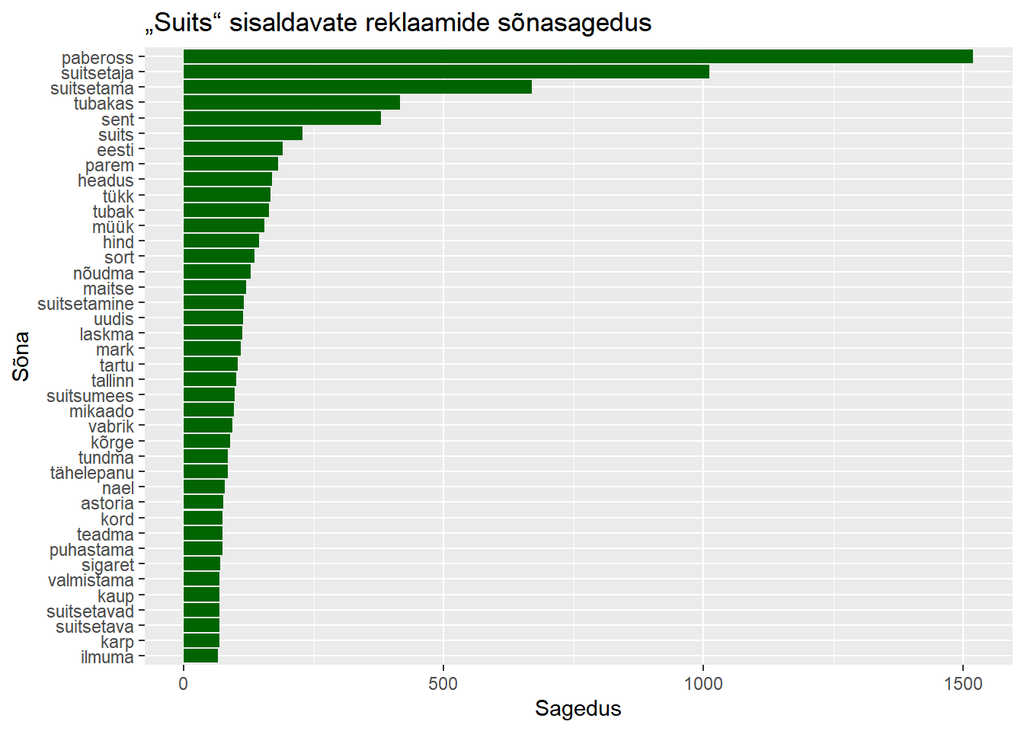

```r
#4 eraldi sagedustabelit
sagedus_suits <- sonasagedusefunktsioon(suits)
sagedus_tubak <- sonasagedusefunktsioon(tubak)
sagedus_sigar <- sonasagedusefunktsioon(sigar)
sagedus_pabeross <- sonasagedusefunktsioon(pabeross)

ggplot(sagedus_suits[1:40, ], aes(x = reorder(word, n), y = n)) +
  geom_col(fill = "darkgreen") +
  coord_flip() +
  labs(x = "Sõna", y = "Sagedus", title = "„Suits“ sisaldavate reklaamide sõnasagedus")
```

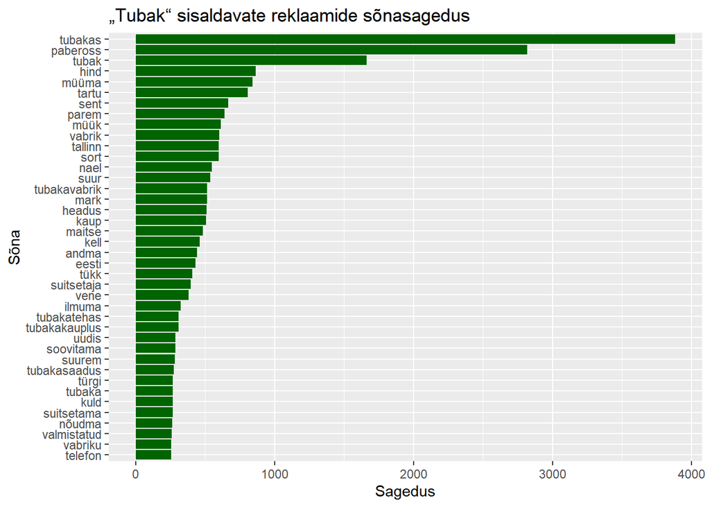

```r
ggplot(sagedus_tubak[1:40, ], aes(x = reorder(word, n), y = n)) +
  geom_col(fill = "darkgreen") +
  coord_flip() +
  labs(x = "Sõna", y = "Sagedus", title = "„Tubak“ sisaldavate reklaamide sõnasagedus")
```

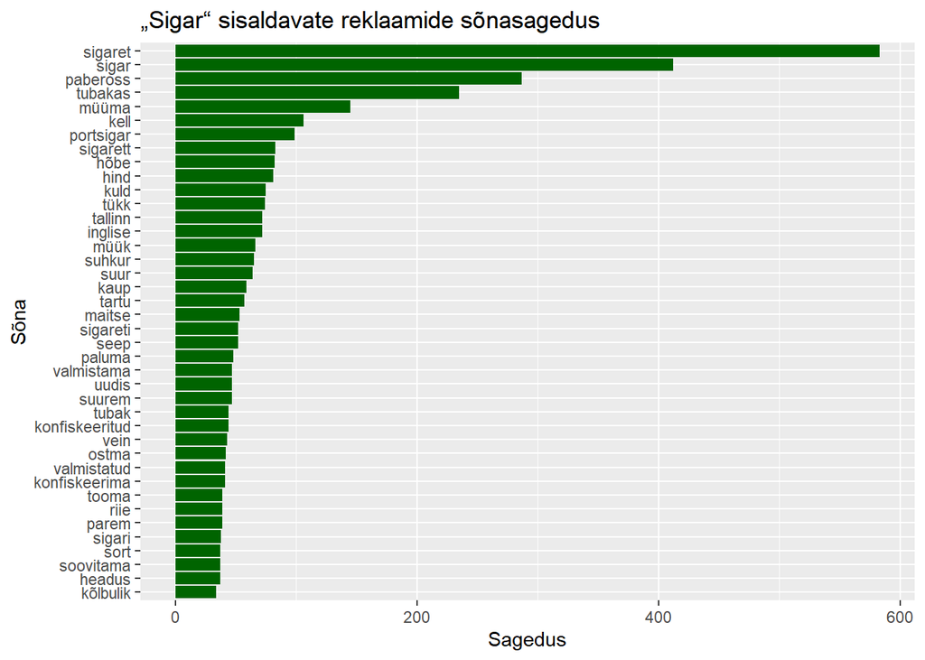

```r
ggplot(sagedus_sigar[1:40, ], aes(x = reorder(word, n), y = n)) +
  geom_col(fill = "darkgreen") +
  coord_flip() +
  labs(x = "Sõna", y = "Sagedus", title = "„Sigar“ sisaldavate reklaamide sõnasagedus")
```

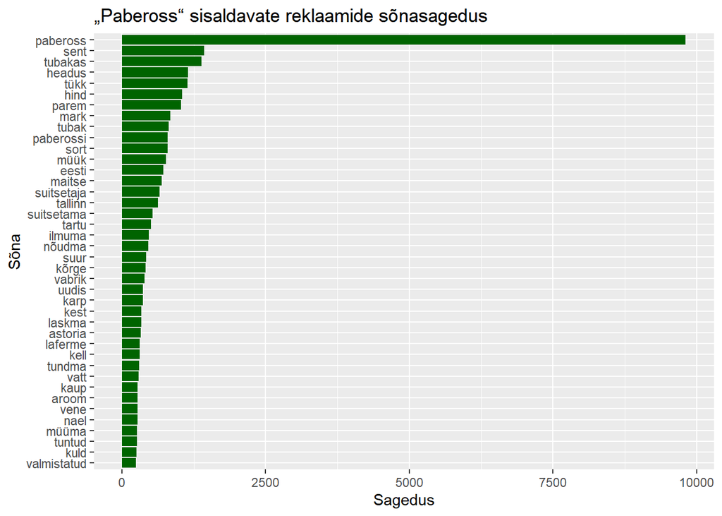

```r
ggplot(sagedus_pabeross[1:40, ], aes(x = reorder(word, n), y = n)) +
  geom_col(fill = "darkgreen") +
  coord_flip() +
  labs(x = "Sõna", y = "Sagedus", title = "„Pabeross“ sisaldavate reklaamide sõnasagedus")
```

### Vaatame sigarettide ja paberosside populaarsust

Ei ole võrreldav/mõõdetav, kuna sigar* reklaame liiga vähe. Sõna “sigaret*” annab ca 800 tulemust 20 aasta perioodil.

### “Suits” bigrammid

```r
bigrams <- suits %>%
  unnest_tokens(bigram, context, token = "ngrams", n = 2) %>%
  filter(str_detect(bigram, regex("suits\\w*", ignore_case = TRUE)))

print(bigrams)
```

[output not shown]

### Tubakareklaamikorpuse kollokatsioonid

```r
library(quanteda)
library(quanteda.textstats)

corp <- corpus(paevalehe_reklaamid, text_field = "context")
#pane sinna mittesuitsetaja corpus(mittesu....), sama pabeross suotis sigar jne

stoppsonad <- readLines("https://datadoi.ee/bitstream/handle/33/78/estonian-stopwords-lemmas.txt?sequence=1&isAllowed=y")

toks <- tokens(
  corp,
  remove_punct = TRUE,
  remove_symbols = TRUE,
  remove_numbers = TRUE
)

toks <- tokens_remove(toks, pattern = "^[[:alpha:]]{1,3}$", valuetype = "regex")

toks <- tokens_remove(toks, pattern = stoppsonad)

cols <- textstat_collocations(
  toks,
  size = 2,
  min_count = 5
)

head(cols, 20)
```

```
##           collocation count count_nested length    lambda        z
## 1           tükk sent   416            0      2  4.396121 66.15785
## 2           tükk mark   361            0      2  4.777020 65.48844
## 3        kõrge headus   262            0      2  5.411328 56.30165
## 4         ilmuma müük   237            0      2  4.860971 55.36139
## 5         müük laskma   211            0      2  5.394198 52.41734
## 6        maitse aroom   157            0      2  5.115358 47.66047
## 7           nael mark   156            0      2  4.413392 44.45069
## 8         kõrgem sort   134            0      2  5.582551 43.57771
## 9    vabrik puhastama    86            0      2  6.167614 41.64942
## 10        a-s astoria   100            0      2  5.148630 41.03238
## 11        kapsas kaal    86            0      2  8.182901 40.94812
## 12          o-ü tubak   151            0      2  5.406083 40.79166
## 13    wabriku telefon    83            0      2  5.812147 40.28673
## 14     wabrik wabriku   307            0      2 10.084172 39.75928
## 15         kohv kakao    67            0      2  7.779970 38.33651
## 16        kilu sprott    93            0      2  9.504521 37.44605
## 17       sprott juust    75            0      2  9.005795 36.94316
## 18      sort pabeross   332            0      2  2.518920 36.68856
## 19 pabeross paberossi   710            0      2  6.077000 36.19045
## 20     parem pabeross   363            0      2  2.261629 35.79463
```

### 1930. aasta kollokatsioonid ehk pneumaatiliselt puhastatud tubakas

```r
paevalehe_reklaamid_1930 <- paevalehe_reklaamid %>%
  filter(year == 1930)

library(quanteda)
library(quanteda.textstats)

corp <- corpus(paevalehe_reklaamid_1930, text_field = "context")
#pane sinna mittesuitsetaja corpus(mittesu....), sama pabeross suotis sigar jne

stoppsonad <- readLines("https://datadoi.ee/bitstream/handle/33/78/estonian-stopwords-lemmas.txt?sequence=1&isAllowed=y")

toks <- tokens(
  corp,
  remove_punct = TRUE,
  remove_symbols = TRUE,
  remove_numbers = TRUE
)

toks <- tokens_remove(toks, pattern = "^[[:alpha:]]{1,3}$", valuetype = "regex")

toks <- tokens_remove(toks, pattern = stoppsonad)

cols <- textstat_collocations(
  toks,
  size = 2,
  min_count = 5
)

head(cols, 20)
```

```
##              collocation count count_nested length   lambda        z
## 1              tükk sent   178            0      2 5.128150 30.95423
## 2      puhastama tubakas   129            0      2 5.022110 29.47322
## 3       vabrik puhastama    85            0      2 5.264447 27.87927
## 4  tubakas pneumaatiline   113            0      2 5.664051 25.76296
## 5           maitse aroom    48            0      2 5.847336 23.48620
## 6            müük laskma    50            0      2 6.887142 23.22036
## 7           kollane kest    44            0      2 5.350068 22.29540
## 8     pneumaatiline viis    85            0      2 7.963728 22.25528
## 9              viis tolm    78            0      2 7.496819 21.42603
## 10     kahjulik lisandus    67            0      2 8.622780 21.12253
## 11     wabriku puhastama    52            0      2 5.935619 20.14321
## 12         tolm kahjulik    75            0      2 8.311986 20.11613
## 13          headus aroom    30            0      2 4.255855 17.83772
## 14           peen maitse    37            0      2 7.046893 17.62400
## 15       nõudma igalpool    20            0      2 6.552084 16.89989
## 16            kohv kakao    30            0      2 8.995842 16.88555
## 17     kõiksugu ekstrakt    19            0      2 7.315392 16.85001
## 18            linda nora    19            0      2 7.457732 16.72188
## 19           kilu sprott    36            0      2 9.374061 16.71442
## 20     tähelepanu wabrik    22            0      2 4.602639 16.58413
```

```r
df_mai_1932 <- subset(
  paevalehe_reklaamid,
  substr(as.character(dateraw), 1, 6) == "193205"
)

df_august_1927 <- subset(
  paevalehe_reklaamid,
  substr(as.character(dateraw), 1, 6) == "192708"
)

df_veebruar_1935 <- subset(
  paevalehe_reklaamid,
  substr(as.character(dateraw), 1, 6) == "193502"
)

df_november_1925 <- subset(
  paevalehe_reklaamid,
  substr(as.character(dateraw), 1, 6) == "192511"
)
```

Nüüd tuleb firmadepõhine analüüs, kus kasutame tubakakorpust.

```r
firmad <- c("Laferme", "Sirena", "Katlama", "Regina", "Havanna", "Sultan Flor", "Reier", "Astoria", "H. Anton", "Kungla", "Steinberg", "Leo Scheer", "Osman", "\\bETK\\b")

top7firmat <- c("Laferme", "Sirena", "Regina", "Havanna", "Astoria", "H. Anton", "ETK")
#Tegelt peaks analüüsima vaid Laferme, mille alla lisandub Havanna.
#Astoria, mis on hiljem Regina ja H. Anton
#Sirena oli OÜ "Tubak", seda raske filterdada vb "o-ü tubak"
#ETK
```

```r
#Ei ole vajalik, kuna kaubamärke oli mustmiljon selle 20 aasta perioodi vältel.

brands <- c("Baar", "Stella", "Diva", "Niilus", "Manon", "Orient", "Lia", "Malta", "Ekstra", "Kasulik", "Special")

paevalehe_reklaamid$brand <- str_extract(paevalehe_reklaamid$context, str_c(brands, collapse = "|"))

brand_counts <- paevalehe_reklaamid %>%
  count(brand, sort = TRUE)

brand_counts <- brand_counts[!is.na(brand_counts$brand), ]

ggplot(brand_counts, aes(x = reorder(brand, n), y = n)) +
  geom_bar(stat = "identity", fill = "blue", color = "black") +
  coord_flip() +
  theme_minimal() +
  labs(title = "Brändisagedus", x = "Bränd", y = "Sagedus")
```

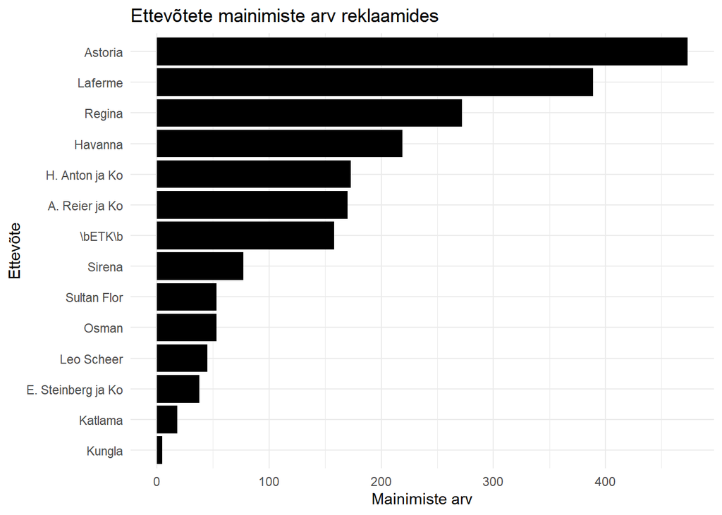

```r
firmadelist_reklaamidega <- list()

#loop, mis asendab kõik vigased "ja"d ja
for (ettevote in firmad) {
  ettevote <- gsub("\\[ja&\\]", "ja|&", ettevote)
  ettevote <- gsub("\\[AE\\]", "A|E", ettevote)

  #H. Anton ja ETK parandused
  if (ettevote == "H. Anton") {
    search_pattern <- "H\\.\\s*Anton"
  } else if (ettevote == "\\bETK\\b") {
    search_pattern <- "\\bETK\\b"
  } else {
    search_pattern <- ettevote
  }

  #otsib firmanimesid paevalehe reklaamidest
  firmadelist_reklaamidega[[ettevote]] <- paevalehe_reklaamid[grepl(search_pattern, paevalehe_reklaamid$context, ignore.case = TRUE, perl = TRUE), ]
}

#tabel, mis näitab kui palju on leitud ridu mis ettevõttel
firmamainimine_reklaamidega <- data.frame(Ettevote = character(), LeitudRidadeArv = numeric())

#loeb mainimisi
for (ettevote in names(firmadelist_reklaamidega)) {
  if (nrow(firmadelist_reklaamidega[[ettevote]]) > 0) {
    firmamainimine_reklaamidega <- rbind(firmamainimine_reklaamidega,
                                     data.frame(Ettevote = ettevote,
                                                LeitudRidadeArv = nrow(firmadelist_reklaamidega[[ettevote]])))
  }
}

#kui 0 mainimist, siis viskan välja data framest
firmamainimine_reklaamidega <- firmamainimine_reklaamidega %>%
  filter(LeitudRidadeArv != 0) %>%
  arrange(desc(LeitudRidadeArv))

#ggplot
ggplot(firmamainimine_reklaamidega, aes(y = reorder(Ettevote, LeitudRidadeArv), x = LeitudRidadeArv)) +
  geom_bar(stat = "identity", fill = "black") +
  scale_y_discrete(labels = c("Reier" = "A. Reier ja Ko", "H. Anton" = "H. Anton ja Ko", "Steinberg" = "E. Steinberg ja Ko")) +
  theme_minimal() +
  theme(axis.text.x = element_text(angle = 0)) +
  labs(x = "Mainimiste arv", y = "Ettevõte", title = "Ettevõtete mainimiste arv reklaamides")
```

```r
#panen cowploti
count_plots <- list()
freq_plots <- list()


for (nimi in top7firmat) {
  if (nimi == "H. Anton") {
    search_pattern <- "H\\.\\s*Anton"
  } else if (nimi == "ETK") {
    search_pattern <- "\\bETK\\b"
  } else {
    search_pattern <- nimi
  }

  #vana paragraafidega loop - populeerib veergu
  paevalehe_reklaamid[[nimi]] <- paevalehe_reklaamid$context %>%
    gsub("<p>", "@@@@<p>", .) %>%
    gsub("<\\/p>", "</p>@@@@", .) %>%
    str_split(., "@@@@") %>%
    lapply(., function(x) x %>%
             grep(search_pattern, ., ignore.case = TRUE, value = TRUE) %>%
             paste(., collapse = " ")) %>%
    unlist()

  #võtab mainimiste hulga vastavalt aastale
  assign(paste0(nimi, "_mainimiste_arv"), paevalehe_reklaamid %>%
           group_by(year) %>%
           summarise(mainimiste_arv = sum(nchar(get(nimi)) > 0)))

  #paneb mainimiste hulga plotile
  plot_count <- ggplot(get(paste0(nimi, "_mainimiste_arv")), aes(x = year, y = mainimiste_arv)) +
    geom_point() +
    geom_line() +
    theme_minimal() +
    labs(x = "Aasta", y = "Mainimiste arv",
         title = paste0(nimi, " reklaamide hulk aastatel"))

  # cowploti jaoks paneb sinna
  count_plots[[nimi]] <- plot_count


  #joon
  fir.m <- lm(mainimiste_arv ~ year, data = get(paste0(nimi, "_mainimiste_arv")))
  summary(fir.m)
}


# kogu_mainimiste_arv <- bind_rows(lapply(top7firmat, function(nimi)
#   get(paste0(nimi, "_mainimiste_arv")) %>% mutate(firma = nimi)))

# ggplot(data = kogu_mainimiste_arv) +
#   geom_line(aes(x = year, y = mainimiste_arv, group = firma, color = firma), size = 1.2) +
#   scale_x_continuous(breaks = seq(min(kogu_mainimiste_arv$year), max(kogu_mainimiste_arv$year), by = 2)) +
#   theme_light() +
#   labs(x = "Aasta",
#        y = "Mainimiste arv",
#        title = "Firmade mainimiste arv aastate lõikes",
#        color = "Ettevõte")

#sonasageduse loop
firmade_sonasagedus <- list()

for (nimi in top7firmat) {
  if (nimi == "H. Anton") {
    search_pattern <- "H\\.\\s*Anton"
  } else if (nimi == "ETK") {
    search_pattern <- "\\bETK\\b"
  } else {
    search_pattern <- nimi
  }

  firma_reklaamid <- paevalehe_reklaamid %>%
    filter(grepl(search_pattern, context, ignore.case = TRUE))

  firma_sonasagedus <- firma_reklaamid %>%
    unnest_tokens(token, context) %>%
    mutate(token = str_remove_all(token, "[0-9]")) %>%
    filter(nchar(token) > 3) %>%
    count(token, sort = TRUE)

  #sonasagedus salvestub tabelisse vastavalt firmanimele
  firmade_sonasagedus[[nimi]] <- firma_sonasagedus
}

#vastavalt firmanimele for loop et printida sõnasageduse
for (vabrik in top7firmat) {
  vabriku_sonasagedus <- firmade_sonasagedus[[vabrik]]

  plot_freq <- ggplot(vabriku_sonasagedus[1:20, ], aes(x = reorder(token, n), y = n)) +
    geom_col(fill = "black") +
    coord_flip() +
    theme_bw() +
    labs(
    x     = "Sõna",
    y     = "Sagedus",
    title = paste0("Sõnasagedus reklaamides ('", vabrik, "')")
  ) +
  theme(
    # telgede pealkirjad paksuks
    axis.title.x = element_text(face = "bold"),
    axis.title.y = element_text(face = "bold"),
    # telje sildid (sõnad) paksuks
    axis.text    = element_text(face = "bold"),
    # graafiku pealkiri paksuks ja veidi suurem
    plot.title   = element_text(face = "bold", size = rel(0.7)),
  )

  # cowplot
  freq_plots[[vabrik]] <- plot_freq}
```

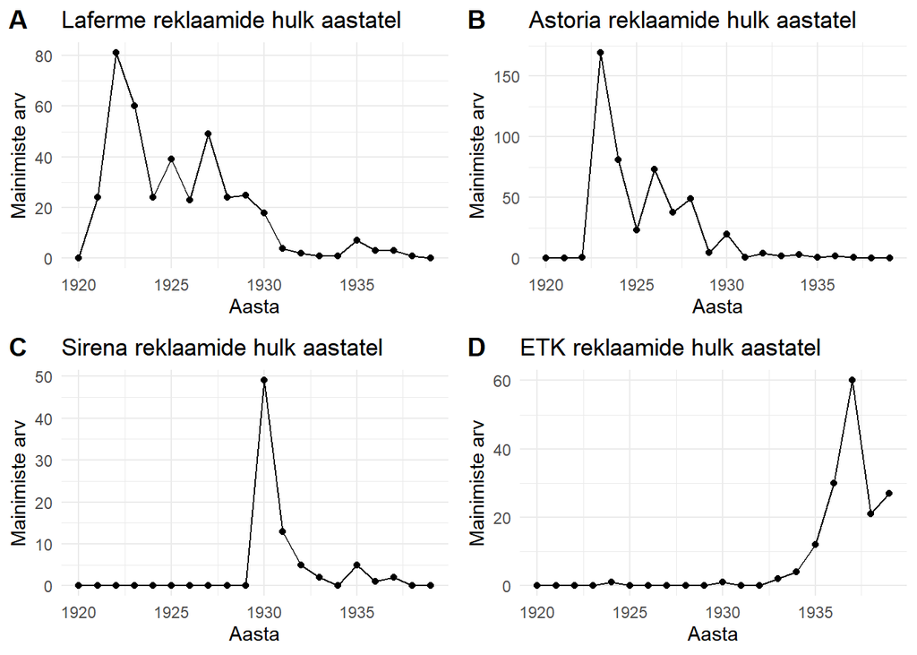

```r
library(cowplot)


# 1) Reklaamide hulk aastatel – 2x2 panel
ad_counts_panel <- plot_grid(
  count_plots$Laferme, count_plots$Astoria,
  count_plots$Sirena,   count_plots$ETK,
  labels = c("A", "B", "C", "D"),
  ncol   = 2
)

# 2) Sõnasagedused – 2x2 panel
word_freqs_panel <- plot_grid(
  freq_plots$Laferme, freq_plots$Astoria,
  freq_plots$Sirena,   freq_plots$ETK,
  labels = c("E", "F", "G", "H"),
  ncol   = 2
)

print(ad_counts_panel)
```

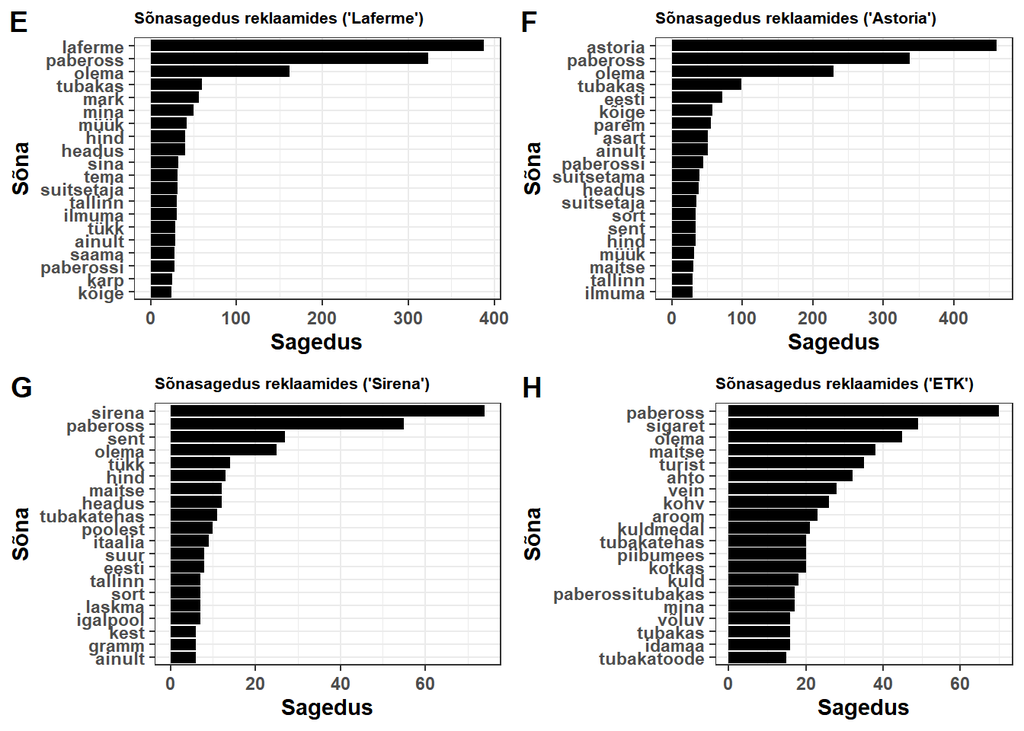

```r
print(word_freqs_panel)
```

Kõik teadaolevad tubakaettevõtted 1920.-1930. aastatel: AS „Laferme“ , OÜ „Tubak“, AS „Regina“, OÜ „Havanna“, „Sultan Flor“, AS „A. Reier & Ko“, AS „Astoria“ ning „H. Anton ja Ko“, Tubakavabrik „Ka De We“, Eesti Tarvitajateühisuste Keskühisus (ETK), AS „Sirena“ ning „B. Katlama“

Väiksemad ettevõtted:

Tubakavabrik „Eslon“ Tubakavabrik „Kungla“, omanikuks August Ney Paberossitehas „Aino“ omanik Lugenberg & Ko Tubakatehas E. Steinberg & Ko Tubakavabrik AS “Leo Scheer” Tallinna sigaritehas Kubana, rajas N. Leinbok Johannes Jostoville paberossitehas Jaan Kanguri tubakavabrik Seeberg ja Kirsch paberossitehas Emiil Silbergi tubaka-ja paberossitehas „Siiwa“